# The shape of sound: A new R package that crosses the bridge between Bioacoustics and Geometric Morphometrics - Rocha - - Methods in Ecology and Evolution - Wiley Online Library

[Methods in Ecology and Evolution](https://besjournals.onlinelibrary.wiley.com/journal/2041210x)

[Early View](https://besjournals.onlinelibrary.wiley.com/toc/2041210x/0/0)

[figure not shown]

APPLICATION

Free Access

# The shape of sound: A new R package that crosses the bridge between Bioacoustics and Geometric Morphometrics

[Pedro C. Rocha](https://besjournals.onlinelibrary.wiley.com/action/doSearch?ContribAuthorStored=Rocha%2C+Pedro+C)

[Pedro S. R. Romano](https://besjournals.onlinelibrary.wiley.com/action/doSearch?ContribAuthorStored=Romano%2C+Pedro+S+R)

First published: 22 February 2021

https://doi.org/10.1111/2041-210X.13580

## Abstract

1. The field of Bioacoustics has flourished in the past few decades, with numerous initiatives towards its application as a tool for biodiversity conservation. Despite the development of new methods involving computational programming and machine learning algorithms, higher accuracy is still needed for species identification, which is why we present herein the new SoundShape package for R platform.
2. The new package focuses on implementing the eigensound method, a promising, and yet little explored protocol for bioacoustical analysis. The eigensound function is the main feature of SoundShape, allowing its user to convert sound waves into a dataset that can be analysed similar to coordinate sets from Geometric Morphometrics Methods, thus enabling the direct comparison between stereotyped calls from different species. Besides, SoundShape also features complementary functions for basic analysis of quantitative variation and illustration of hypothetical sound shapes representing the sample of sounds.
3. Implementation of SoundShape is summarized through a workflow guide, using data from the new package. The sample study resulted in nearly 90% variation expressed in an ordination plot, therefore successfully summarizing complex sound waves previously described by large datasets of amplitude values. Moreover, we also introduce two addendums to eigensound: (a) three steps to prevent errors and biased results—aimed at securing a meaningful comparison between acoustic units from different species; and (b) the option of applying a logarithmic grid on the *x*‐axis (time)—which emphasizes short duration calls while also encompassing long ones.
4. SoundShape package now provide the tools required for anyone to replicate and implement the eigensound method on the r platform. This will enable future studies to focus on further exploring the applications of sound shape analysis on various scientific areas, including (but not limited to) taxonomy, systematics, evolution, acoustic niche partitioning, soundscape ecology and machine learning algorithms focused on species identification for conservation biology.

## 1 INTRODUCTION

Bioacoustics is a multidisciplinary field focused on animal communication, behaviour and the physics of sound production (Fletcher, 2007). In the past few decades, there has been a growing interest for the potential usage of animal sounds in environmental conservation (Laiolo, 2010; Xie et al., 2020), with initiatives towards its application as a tool for biodiversity assessment and monitoring (Krause, 2008; Pijanowski et al., 2011; Rowley et al., 2019; Sueur & Farina, 2015) as well as the development of new methods involving machine learning algorithms for species identification (LeBien et al., 2020; Towsey et al., 2014; Xie et al., 2018). However, higher accuracy is still needed (Sueur & Farina, 2015), which was our main objective when we developed the new SoundShape package (Rocha, 2020) for r platform (R Core Team, 2020).

The new package provides the tools required to implement a promising, and yet little explored method for bioacoustical analysis, the eigensound protocol developed by MacLeod et al. (2013). The method consists of applying a sampling grid over the 3D representation of sound (i.e. spectrogram data) and then translating the spectrogram into a dataset that can be analysed similar to coordinate sets used in Geometric Morphometrics Methods (GMMs), thus enabling the direct comparison between stereotyped calls from different species. By doing so, MacLeod et al. (2013) successfully discriminated bat species previously indistinguishable using standard protocols of bioacoustical analysis (e.g. Walters et al., 2012).

Despite being well‐described by MacLeod et al. (2013), the eigensound method lacked a free and open platform to run the analysis. SoundShape package aims to fill this applicability gap, with functions that enable anyone familiar with r to easily go from sound waves to principal component analysis (PCA), using tools and codes from traditional bioacoustics (i.e. tuneR and seewave packages; Sueur et al., 2008; Ligges et al., 2018), geometric morphometrics (i.e. geomorph package; Adams et al., 2020) and multivariate analysis (e.g. stats package; R Core Team, 2020).

Although we briefly present a step by step guide to eigensound analysis using SoundShape, the Supplementary File provides detailed instructions and r codes for anyone to replicate, implement or enhance the analysis using the new package. Moreover, we also included two addendums to eigensound: (a) three steps that avoid errors and biased results; and (b) the option of applying a logarithmic grid on the *x*‐axis (time)—which emphasizes short duration calls while also encompassing long ones.

## 2 PACKAGE OVERVIEW

SoundShape package was developed for the r platform as a set of functions that allow the implementation of eigensound method as described by MacLeod et al. (2013) (Figure 1; see Supplementary File for details on eigensound). The main feature of SoundShape is the eigensound function, which allows its users to acquire, and simultaneously store point coordinates (i.e. semilandmarks; sLM; see MacLeod et al., 2013 for details on sonic sLM) as an r object, and/or in TPS format—the native file format of F. James Rohlf TPS series (Rohlf, 2015)—that can be used by numerous software of GMM. Moreover, eigensound also allows the exportation of 2D spectrogram images that are helpful during the three steps to prevent errors and biased results (Section 3.3).

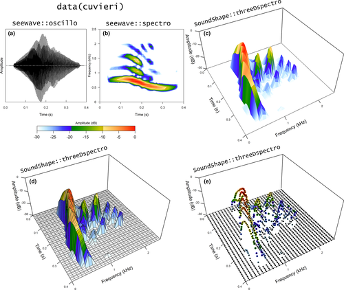

**FIGURE 1**

Open in figure viewer[PowerPoint](https://besjournals.onlinelibrary.wiley.com/action/downloadFigures?id=mee313580-fig-0001&doi=10.1111%2F2041-210X.13580)

Graphical outputs using cuvieri sample from SoundShape. (a) Oscillogram created with oscillo function (seewave package); (b) 2D spectrogram calculated with spectro function (seewave). Graphics created with threeDspectro function from SoundShape: (c) 3D spectrogram, (d) 3D spectrogram with sampling grid and (e) 3D spectrogram as points (i.e. sLM)

In addition to eigensound, SoundShape also contains functions for plotting 3D spectrograms as points or surfaces (i.e. threeDspectro function; Figure 1), alignment of acoustic units within a standardized sound window (i.e. align.wave), the ordination of principal components (PCs) from the output of a PCA (i.e. pca.plot) and the calculation of hypothetical 3D plots based on PCs (i.e. hypo.surf). Although these functions can be implemented on any given set of sounds, SoundShape includes samples of data, which were employed in the empirical study presented below.

## 3 WORKFLOW USING SoundShape PACKAGE

This section summarizes a step by step guide to eigensound analysis using samples embedded in SoundShape (i.e. centralis, cuvieri and kroyeri samples of data). Although each topic is briefly explained herein, the Supplementary File contains a complete and detailed guide for sound shape study, including codes and theoretical background.

### 3.1 Definition of homologous acoustic units

Since eigensound is centred around the direct comparison of acoustic units, the foremost step in sound shape study is the careful selection of units from which the analysis will be conducted. In GMM studies, this homology criterion is achieved through a least‐squares fit of Generalized Procrustes Analysis (GPA), which generally accounts for the general similarity and topology of morphological LMs (Zelditch et al., 2012). However, even though several authors argue that acoustic traits constrained by anatomical structures (e.g. dominant frequency, pulse rate) are more conservative than those under the direct influence of behaviour (e.g. call duration, interval between calls), the criteria for homologous sound comparison may vary across different animal groups (see Supplementary File for examples and more on homology between animal sounds). Therefore, we recommend a throughout literature review before the definition of acoustic units. Herein, we adopted a physiological definition of ‘note’, (McLister et al., 1995; Robillard et al., 2006), which led to an unambiguous selection of acoustic units (Figure 2).

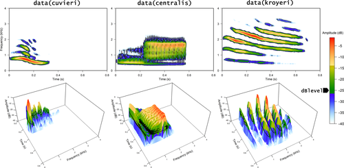

**FIGURE 2**

Open in figure viewer[PowerPoint](https://besjournals.onlinelibrary.wiley.com/action/downloadFigures?id=mee313580-fig-0002&doi=10.1111%2F2041-210X.13580)

Acoustic units with relative amplitude contours highlighted by black lines (dBlevel = 25 dB). Spectrogram images (2D above, 3D below) generated using eigensound function with samples cuvieri, centralis and kroyeri. Units aligned at the beginning of a sound window using align.wave

### 3.2 Store acoustic units as separate files

The eigensound function acquires point coordinates (sLM) from multiple Waveform Audio File Format (WAV files). Each WAV file should represent a homologous acoustic unit (see Section 3.1) and be stored on the same folder from the user's console.

### 3.3 Addendum: Three steps that avoid errors and biased results

The sLM are automatically acquired using eigensound, meaning that this approach does not add human errors from sLM digitalization. Despite that, the eigensound protocol requires some standardization that would otherwise lead to errors or biased results (MacLeod et al., 2013). These can be divided into the following three steps, which are aided by the functions align.wave and eigensound.

#### 3.3.1 Define sound window dimensions

Sound window dimensions are represented by the time (*x*‐axis) and frequency (*y*‐axis) limits for spectrogram images (MacLeod et al., 2013). Time limits should be based on the acoustic unit with the longest duration within the sample, whereas frequency limits consider the unit with the largest frequency bandwidth. In the present sample study, the longest units were also the ones with broader frequency bandwidths (i.e. kroyeri sample; Figure 2).

#### 3.3.2 Alignment of units at the beginning of a sound window

To ensure that variation is due to energy shifts within the acoustic unit, and not because of changes in their relative position in the sound window, the eigensound protocol requires units to be placed at the beginning of a sound window before proceeding with the analysis (MacLeod et al., 2013). align.wave function automatically aligns the units at the beginning of a sound window, while also standardizing the durations of WAV files (see Section 3.3.1; see also Supplementary File for details on align.wave function). This grants that all sounds from the study will fit the intended window length, while also beginning at the same time value.

#### 3.3.3 Set relative amplitude background

The relative amplitude value will be used as background in the spectrogram (dBlevel; Figure 2), which aims to minimize the influence of background noise (MacLeod et al., 2013). Despite being arbitrarily chosen as the final step in this protocol for avoiding errors, this parameter can impact both the sound window dimensions and the ideal alignment (Sections 3.3.1 and 3.3.2 respectively). Therefore, every time dBlevel is changed, align.wave has to be run again on the original WAV files. In the present study, we experimentally defined the curve of relative amplitude at −25 dB.

### 3.4 Define sampling grid and run eigensound

In eigensound analysis (MacLeod et al., 2013), each acoustic unit from the sample has a sampling grid applied over the 3D spectrogram data. The number of cells per side in the grid will determine the amount of sLM acquired by eigensound, so the ideal grid should adequate the sound sample, while also representing a dimensionality reduction from spectrogram data (see also Supplementary File). Herein, this criterion led to 70 cells on the time and 47 cells on the frequency (Figure 3), which yield the acquisition of 3,290 sLM per sound unit.

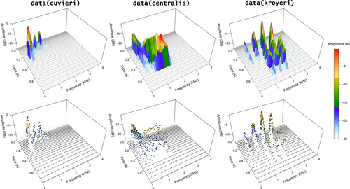

**FIGURE 3**

Open in figure viewer[PowerPoint](https://besjournals.onlinelibrary.wiley.com/action/downloadFigures?id=mee313580-fig-0003&doi=10.1111%2F2041-210X.13580)

3D images of spectrogram data sampled with a logarithmic grid on the *x*‐axis. Above: Simplified sound surface. Below: Coloured sLM representing the intersections from the grid. Spectrogram images exported using eigensound with the samples of centralis, cuvieri and kroyeri

#### 3.4.1 Addendum: A logarithmic scale on the *x*‐axis (time)

If one's sample includes sounds with distinct durations (e.g. from 0.3 s to 0.7 s, as in our sample; Figures 2–3, 2–3), the shorter sounds can display a large ‘blank’ space in the sound window. Consequently, the sLM that represent these sounds will display remarkably similar point configurations (see plots from cuvieri; Figures 2–3, 2–3), whereas the long duration calls will be nicely sampled through the grid (see plots from kroyeri). As a way around this issue, eigensound feature the option of using a logarithmic scale on the time (*x*‐axis), which emphasizes the short sounds while also encompassing the long ones (Figure 3; see also Supplementary File). This can have a major impact on sound shape analysis and future studies should focus on exploring the implications of a logarithmic grid on the time (*x*‐axis).

#### 3.4.2 Run eigensound function

Once the steps for avoiding errors are concluded (Section 3.3) and the sampling grid is defined (Section 3.4), eigensound can now be used to acquire topologically homologous sLM that represent the surface of sound, which are independent of changes in position, alignment and size (MacLeod et al., 2013; see also Supplementary File). Therefore, eigensound analysis requires no more actions before proceeding to a dimensionality reduction procedure that facilitates comparison of acoustic units.

### 3.5 Principal component analysis

In GMM studies, PCA is among the most common ordination methods employed for dimensionality reduction on shape data (Zelditch et al., 2012). Although PCA does not constitute tests of hypothesis per se, it rotates the data allowing the visualization of variation on fewer axes than the original dataset. Besides, ordination plots simplify the description and are widely employed in exploratory data analysis, especially when one is looking for potential grouping to be tested. These plots are facilitated by pca.plot function from SoundShape (Figure 4; see also Supplementary File).

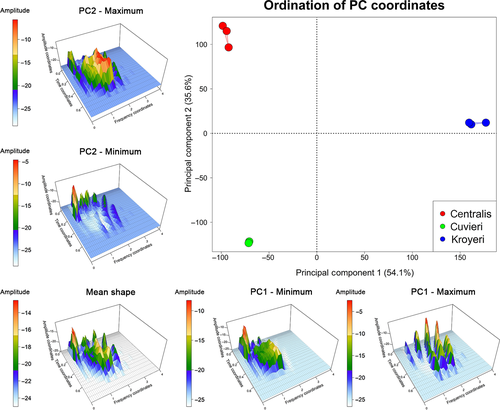

**FIGURE 4**

Open in figure viewer[PowerPoint](https://besjournals.onlinelibrary.wiley.com/action/downloadFigures?id=mee313580-fig-0004&doi=10.1111%2F2041-210X.13580)

Ordination analysis (top right) using pca.plot from SoundShape. Results acquired with eigensound using the samples of centralis, cuvieri and kroyeri. Hypothetical surfaces relative to PCs (left and low edges) represents mean shape, minimum and maximum deformations

Ultimately, the variation embedded in each PC axis can be visualized as hypothetical sound surfaces, which are equivalent to warp grids in shape space from GMM studies (MacLeod et al., 2013). These surfaces are calculated using hypo.surf function and should be interpreted along with the ordination plots, enhancing the comprehension of how sound shape changed along with each PCs (Figure 4).

### 3.6 Interpreting the outputs of eigensound analysis

The ordination plot represented 89.7% of the whole variance in our dataset (Figure 4), which yielded a clear structuring of acoustic units from different species. The higher positive values of PC1 corresponded to units from kroyeri sample, with clear harmonic structure and broad frequency bandwidth. Lower and negative values of PC1 expressed a hypothetical shape that gathered sonic information from centralis and cuvieri samples. A similar pattern is observed in the PC2 axis, with positive PC2 values referring to broad frequency bandwidth and no harmonic structure (i.e. centralis), and negative PC2 values representing short durations and clear harmonic structure (i.e. cuvieri).

## 4 CONCLUSIONS

SoundShape now provides the tools required for anyone to replicate and implement the eigensound method. Future studies should focus on further exploring the applications of eigensound on various scientific areas, such as soundscape ecology, acoustic niche partitioning, systematics, evolution and taxonomy. Besides, the sLM acquired by eigensound may be submitted to machine learning algorithms, with multiple applications for species identification aimed at conservation biology.

## ACKNOWLEDGEMENTS

The authors thank Jérôme Sueur for helping with early codes. Norman MacLeod provided insights during the development of SoundShape. Carla S. Guimarães helped with images and read early versions of the manuscript. Pedro C. Rocha is grateful to Coordenação de Aperfeiçoamento de Pessoal de Nível Superior for MSc Scholarship.

## CONFLICT OF INTEREST

The authors declare no conflict of interest.

## AUTHORS' CONTRIBUTIONS

P.C.R. developed SoundShape, wrote the main text, Supplementary File and images; P.S.R.R. guided the GMM analysis, contributed throughout the text and figures. Both the authors contributed to manuscript preparation and revision.

[figure not shown]

[Early View](https://besjournals.onlinelibrary.wiley.com/toc/2041210x/0/0)

Online Version of Record before inclusion in an issue

### Details

- © 2021 British Ecological Society

[figure not shown]

### Research funding

  - Coordenação de Aperfeiçoamento de Pessoal de Nível Superior

### Keywords

  - amphibia
  - anura
  - [Eigensound method](https://besjournals.onlinelibrary.wiley.com/action/doSearch?field1=Keyword&text1=Eigensound%20method)
  - [multivariate analysis](https://besjournals.onlinelibrary.wiley.com/action/doSearch?field1=Keyword&text1=multivariate%20analysis)
  - [ordination plot](https://besjournals.onlinelibrary.wiley.com/action/doSearch?field1=Keyword&text1=ordination%20plot)
  - [*Physalaemus*](https://besjournals.onlinelibrary.wiley.com/action/doSearch?field1=Keyword&text1=%0APhysalaemus%0A)
  - [R package](https://besjournals.onlinelibrary.wiley.com/action/doSearch?field1=Keyword&text1=R%20package)
  - semilandmarks

### Publication History

  - Version of Record online: 04 March 2021
  - Accepted manuscript online: 22 February 2021
  - Manuscript accepted: 05 February 2021
  - Manuscript received: 11 November 2020